# Robert Garrett

Statistics Student

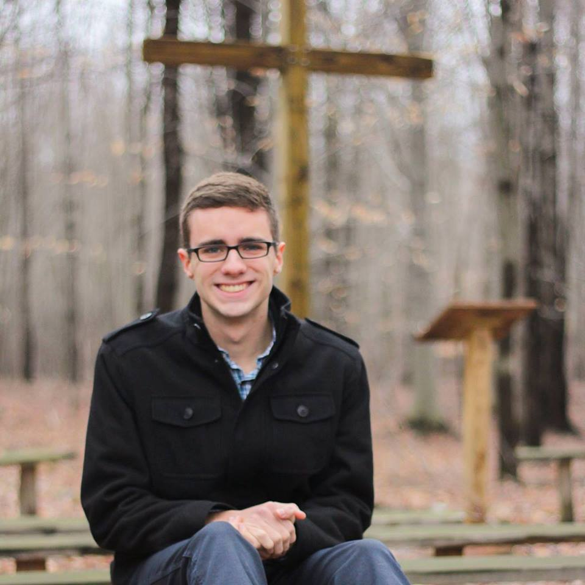

[figure not shown]

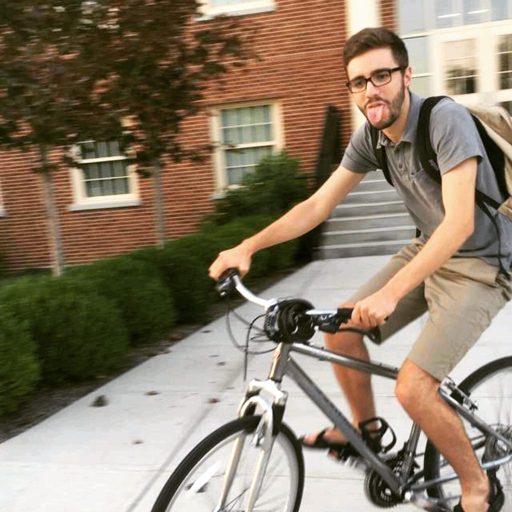

## About me

I’m a recent alumnus of Miami University where I studied Mathematics & Statistics, Predictive Analytics, and Computer Science. This August, I’m starting my first year at the University of Illinois at Urbana-Champaign where I’m pursuing a PhD in Statistics.

## Academic Projects

**2019 DataFest at Miami University:** For my fourth and final year of competing at Miami University’s annual DataFest, my team, the Standard Deviants, [took first place](https://miamioh.edu/fsb/news/2019/04/datafest-2019.html) with our strategy for identifying fatigue in rugby players. See our presentation [here](https://garretrc.github.io/host/StandardDeviants.pptx). It’s been an honor to [work with my good friend Bob Krueger](https://miamioh.edu/fsb/centers/cads/news/bob-and-rob/index.html) all four years, as well as many others including Bri Clements, Katherine Shockey, Ben Smith, Austin Nar, Sanchit Ram Arvind, Alison Tuiyott, Prasidh Arora, and David Black.

**2018 DataFest at Miami University:** My team (ANOVA One Bites the Dust) [placed first](http://miamioh.edu/fsb/fsbnews/?up=/news/180409132653%20Datafest%202018) in Miami University’s 2018 DataFest with our analysis of Indeed.com’s job listing data. Using regional information to link the dataset to US Census Bureau data, we were able to create a metric for talent/job listing imbalances in US metropolitan areas. See our full presentation [here](https://garretrc.github.io/host/ANOVAdatafest.pdf), and check out our ggvoronoi package for some tools we developed during the competition!

**2017 GSS Data Challenge:** During the spring and summer of 2017 I worked with a team of students to analyze the Bureau of Labor Statistics Consumer Expenditure Survey Data. We leveraged the data to view the effect of the Great Recession on individual consumers. In July 2017, I traveled to Baltimore, MD and presented our findings at the Joint Statistical Meetings. We placed third in the competition despite being the only undergraduate team to participate! I am currently working to summarise our work and submit a paper to the *JSM Proceedings* and *Computational Statistics*.

**2017 DataFest at Miami University:** My friends and I placed third with our analysis of browsers vs. buyers on Expedia. Check out our [presentation](https://garretrc.github.io/host/SQLpaper.pdf) and alluvial diagram.

**2017 PittBusiness Analytics Case Competition:** I traveled to Pittsburgh to compete in this competition with some of my classmates at Miami. We created a [data-centric process](https://garretrc.github.io/host/pittsburgh2017.pdf) for determining market potential of our product.

**2016 GSS Data Challenge:** Starting January 2016, I worked with a team to scrape, wrangle and visualize data for car accidents (GES National Automotive Sampling System) and crash safety ratings (From the NHTSA and IIHS). [paper](https://garretrc.github.io/host/gssPaper.pdf) and [R Shiny App](http://dataviz.miamioh.edu/nhtsaGesAnalysis/) that was presented at the 2016 Joint Statistical Meetings. We are currently working on modeling probabilities of injuries in order to prepare our work to be submitted to *Computational Statistics*.

**2016 DataFest at Miami University:** I participated in Miami’s first annual DataFest, where my team of first-year classmates won Best in Show. See a picture of the team up top and [see our findings and data visualizations](https://garretrc.github.io/host/datafestsub.pdf) of our ad suggestion algorithms for TicketMaster.

## Personal Projects

**ggvoronoi:** An R package for creating quick and customizable Voronoi Choropleth Diagrams with ggplot2. Built with my friend Austin Nar based on our work at DataFest 2018. Tutorial here: ggvoronoi.R and repository on my [github](https://github.com/garretrc/ggvoronoi).

**Nodesplosion:** A game playable on any connected, undirected graph based on the premise that a node can hold as many dots as its number of edges and explodes its dots into its neighbors upon surpassing that capacity. Made as a fun project along with Bob Krueger, Robbie Ritchie and John Biggs. Playable on my website at garretrc.github.io/splode.

**DataFest Inspiration:** A quick set of visualizations and projects to serve as inspiration for data competitions on my [Pinterest](https://www.pinterest.com/garrettr223/datafest/).